# Predicting survival times for neuroblastoma patients using RNA-seq expression profiles

Authors

Tyler Grimes

Alejandro R. Walker

Susmita Datta

Somnath Datta

Published

May 30, 2018

In [*Biology Direct*](https://biologydirect.biomedcentral.com/articles/10.1186/s13062-018-0213-x)

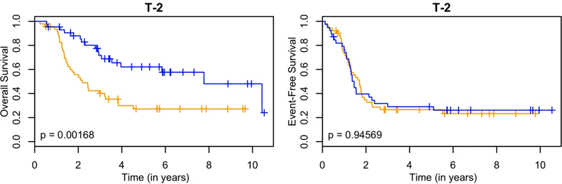

## Abstract

**Background:** Neuroblastoma is the most common tumor of early childhood and is notorious for its high variability in clinical presentation. Accurate prognosis has remained a challenge for many patients. In this study, expression profiles from RNA-sequencing are used to predict survival times directly. Several models are investigated using various annotation levels of expression profiles (genes, transcripts, and introns), and an ensemble predictor is proposed as a heuristic for combining these different profiles.

**Results:** The use of RNA-seq data is shown to improve accuracy in comparison to using clinical data alone for predicting overall survival times. Furthermore, clinically high-risk patients can be subclassified based on their predicted overall survival times. In this effort, the best performing model was the elastic net using both transcripts and introns together. This model separated patients into two groups with 2-year overall survival rates of 0.40±0.11 (n=22) versus 0.80±0.05 (n=68). The ensemble approach gave similar results, with groups 0.42±0.10 (n=25) versus 0.82±0.05 (n=65). This suggests that the ensemble is able to effectively combine the individual RNA-seq datasets.

**Conclusions:** Using predicted survival times based on RNA-seq data can provide improved prognosis by subclassifying clinically high-risk neuroblastoma patients.

## Summary

In this study, expression profiles from RNA-sequencing of Neuroblastoma tumor samples are used to predict patient survival times. Several models are investigated using various annotation levels of expression profiles (genes, transcripts, and introns), and an ensemble predictor is proposed as a heuristic for combining these different profiles. The use of RNA-seq data is shown to improve accuracy in comparison to using clinical data alone for predicting overall survival times.

[Source code](https://github.com/tgrimes/CAMDA-2017-Neuroblastoma) [Slides](https://tgrimes.github.io/files/presentations/CAMDA_2017.pptx)

Back to top